# Regresión Lineal con ggplot usando el método lm: Slant Up

Paul Astudillo

2024-10-08

# Introducción

En este análisis, utilizamos el conjunto de datos “slant_up” del paquete datasauRus, que forma parte de una colección conocida como DataSaurus. Esta colección contiene diferentes datasets que, a pesar de tener estadísticas similares, presentan patrones visuales muy variados. Esto demuestra la importancia de visualizar los datos, ya que la representación gráfica puede revelar información que no es evidente a partir de estadísticas descriptivas.

En esta sección, primero cargamos las librerías necesarias, incluyendo ggplot2 para la visualización de datos y dplyr para el manejo de datos. ggplot es una herramienta muy útil porque permite crear gráficos de manera sencilla y flexible, facilitando el análisis visual de las relaciones entre variables. Posteriormente, filtramos el conjunto de datos para centrarnos en “slant_up”. A continuación, generamos un gráfico de dispersión que muestra la relación entre las variables x e y, y añadimos una línea de regresión lineal utilizando el método lm. Este método es muy básico y se utiliza comúnmente para modelar la relación entre dos variables cuantitativas. Este análisis nos ayudará a entender mejor la relación entre las variables en este dataset específico.

## Cargar las librerías necesarias

```r
library(datasauRus)
library(ggplot2)
library(dplyr)
```

## Análisis del dataset slant_up

```r
# Filtrar el dataset 'slant_up'
slant_up_data <- datasaurus_dozen %>% filter(dataset == "slant_up")
```

## Gráfico de dispersión con ajuste de regresión lineal

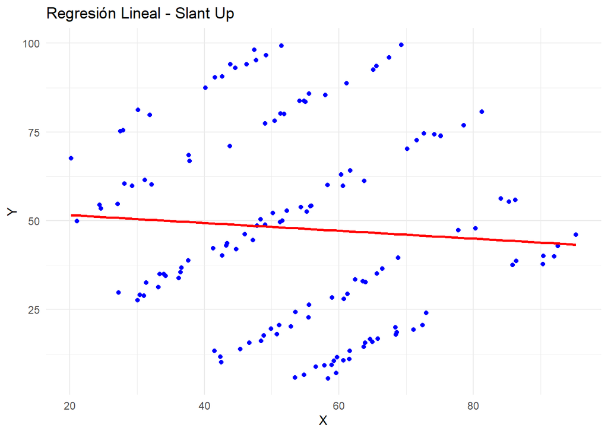

```r
# Gráfico de dispersión con línea de regresión
ggplot(slant_up_data, aes(x = x, y = y)) +
  geom_point(color = "blue") + # Puntos en azul
  geom_smooth(method = "lm", se = FALSE, color = "red") + # Línea de regresión en rojo
  labs(title = "Regresión Lineal - Slant Up", x = "X", y = "Y") + # Etiquetas del gráfico
  theme_minimal() # Tema minimalista
```